# **ExtraaLearn Project**

### **Tuning the AdaBoost Model (GridsearchCV)**

To potentially improve the performance of the AdaBoost Classifier, we will perform hyperparameter tuning using GridSearchCV. This involves searching over a predefined grid of hyperparameter values and evaluating the model's performance (using cross-validation on the training data) for each combination to find the optimal set of parameters.

We will tune the following hyperparameters:

- `n_estimators`: The number of boosting stages to perform.
- `learning_rate`: Shrinks the contribution of each weak regressor.
- `estimator__max_depth`: The maximum depth of the individual decision trees (weak learners). Note the double underscore to access the parameter of the base estimator.

```python
# Define the hyperparameter grid for AdaBoost tuning
param_grid_ada = {
    'n_estimators': [50, 100, 200], # Number of boosting stages
    'learning_rate': [0.01, 0.1, 1], # Step size shrinkage
    'estimator__max_depth': [1, 2, 3] # Max depth of the base estimator (Decision Tree)
}

# Print the defined hyperparameter grid
print("Hyperparameter Grid:", param_grid_ada)
```

```
Hyperparameter Grid: {'n_estimators': [50, 100, 200], 'learning_rate': [0.01, 0.1, 1], 'estimator__max_depth': [1, 2, 3]}
```

```python
# Initialize AdaBoost Classifier model with a Decision Tree as the base estimator
# We need to specify the base estimator to tune its parameters like max_depth
ada_model = AdaBoostClassifier(estimator=DecisionTreeClassifier(random_state=42), random_state=42)

# Initialize GridSearchCV
grid_search_ada = GridSearchCV(estimator=ada_model, param_grid=param_grid_ada,
                               cv=5, scoring='roc_auc', n_jobs=-1, verbose=2)

# Fit GridSearchCV to the training data
print("Starting GridSearchCV fit...")
grid_search_ada.fit(X_train, y_train)
print("GridSearchCV fit complete.")

# Print the best hyperparameters found by GridSearchCV
print("Best hyperparameters found by GridSearchCV:", grid_search_ada.best_params_)
```

```
Starting GridSearchCV fit...
Fitting 5 folds for each of 27 candidates, totalling 135 fits
GridSearchCV fit complete.
Best hyperparameters found by GridSearchCV: {'estimator__max_depth': 3, 'learning_rate': 0.1, 'n_estimators': 200}
```

```python
# Create a copy of the best parameters found by GridSearchCV
best_params = grid_search_ada.best_params_.copy()

# Extract the base estimator's parameters (e.g., 'estimator__max_depth')
best_max_depth = best_params.pop('estimator__max_depth')

# Initialize the best base estimator (Decision Tree) using its specific parameter
best_base_estimator = DecisionTreeClassifier(max_depth=best_max_depth, random_state=42)

# Initialize a new AdaBoost model with the best AdaBoost parameters and the best base estimator
tuned_ada_model = AdaBoostClassifier(estimator=best_base_estimator, **best_params, random_state=42)

# Train the tuned model and measure training time
start_time = time.time()
tuned_ada_model.fit(X_train, y_train)
training_time_tuned_ada = time.time() - start_time

# Make predictions on the training and testing sets and measure prediction time
start_time = time.time()
y_train_pred_tuned_ada = tuned_ada_model.predict(X_train)
train_prediction_time_tuned_ada = time.time() - start_time

start_time = time.time()
y_test_pred_tuned_ada = tuned_ada_model.predict(X_test)
test_prediction_time_tuned_ada = time.time() - start_time

# Get predicted probabilities for the testing set
y_test_proba_tuned_ada = tuned_ada_model.predict_proba(X_test)[:, 1]

# Evaluate the tuned model
test_report_tuned_ada = classification_report(y_test, y_test_pred_tuned_ada, output_dict=True)
test_roc_auc_tuned_ada = roc_auc_score(y_test, y_test_proba_tuned_ada)


# Store results in the dictionary
model_results['Tuned AdaBoost'] = {
    'Training Report': classification_report(y_train, y_train_pred_tuned_ada, output_dict=True),
    'Training ROC AUC': roc_auc_score(y_train, tuned_ada_model.predict_proba(X_train)[:, 1]),
    'Training Confusion Matrix': confusion_matrix(y_train, y_train_pred_tuned_ada).tolist(),
    'Training Time (s)': training_time_tuned_ada,
    'Training Prediction Time (s)': train_prediction_time_tuned_ada,
    'Testing Report': test_report_tuned_ada,
    'Testing ROC AUC': test_roc_auc_tuned_ada,
    'Testing Confusion Matrix': confusion_matrix(y_test, y_test_pred_tuned_ada).tolist(),
    'Testing Prediction Time (s)': test_prediction_time_tuned_ada,
    'Testing Probabilities': y_test_proba_tuned_ada.tolist() # Store testing probabilities
}
print("Tuned AdaBoost model evaluation complete and results stored.")
```

```
Tuned AdaBoost model evaluation complete and results stored.
```

```
Model Comparison Table (Sorted by Test ROC AUC):
```

|  | Accuracy (Train) | Precision (Train - Converted) | Recall (Train - Converted) | F1-score (Train - Converted) | ROC AUC (Train) | Accuracy (Test) | Precision (Test - Converted) | Recall (Test - Converted) | F1-score (Test - Converted) | ROC AUC (Test) | Training Time (s) | Prediction Time (s) |
| --- | --- | --- | --- | --- | --- | --- | --- | --- | --- | --- | --- | --- |
| Tuned Random Forest | 0.911365 | 0.877976 | 0.813419 | 0.844466 | 0.973713 | 0.857609 | 0.800000 | 0.724739 | 0.760512 | 0.928205 | 1.754174 | 0.051781 |
| Tuned AdaBoost | 0.863785 | 0.784675 | 0.743566 | 0.763568 | 0.927920 | 0.867391 | 0.795699 | 0.773519 | 0.784452 | 0.926986 | 2.980228 | 0.061703 |
| Pruned Decision Tree | 0.873029 | 0.802927 | 0.756434 | 0.778987 | 0.925634 | 0.860870 | 0.806950 | 0.728223 | 0.765568 | 0.919101 | 0.028307 | 0.003221 |
| Random Forest | 0.999728 | 0.999082 | 1.000000 | 0.999541 | 1.000000 | 0.858696 | 0.807843 | 0.717770 | 0.760148 | 0.915903 | 0.740377 | 0.023888 |
| AdaBoost | 0.820827 | 0.730893 | 0.624081 | 0.673277 | 0.891255 | 0.831522 | 0.764000 | 0.665505 | 0.711359 | 0.896791 | 0.321103 | 0.015031 |
| Logistic Regression | 0.834693 | 0.769663 | 0.629596 | 0.692619 | 0.867507 | 0.844565 | 0.788000 | 0.686411 | 0.733706 | 0.883454 | 0.063303 | 0.013574 |
| Decision Tree | 0.999728 | 1.000000 | 0.999081 | 0.999540 | 1.000000 | 0.810870 | 0.687708 | 0.721254 | 0.704082 | 0.786378 | 0.035452 | 0.002146 |

```
--- Confusion Matrices for Top 5 Models (Based on Test ROC AUC) ---
```

```
Feature Importances (Tuned AdaBoost):
```

|  | 0 |
| --- | --- |
| first_interaction_Website | 2.756219e-01 |
| time_spent_on_website | 2.294950e-01 |
| profile_completed_Medium | 1.545460e-01 |
| profile_completed_Low | 9.002576e-02 |
| age | 7.915372e-02 |
| page_views_per_visit | 4.956734e-02 |
| current_occupation_Unemployed | 3.371329e-02 |
| last_activity_Phone Activity | 2.117844e-02 |
| referral_Yes | 1.968279e-02 |
| last_activity_Website Activity | 1.372755e-02 |
| digital_media_Yes | 1.108502e-02 |
| website_engagement | 9.023884e-03 |
| interaction_score | 7.404312e-03 |
| website_visits | 3.617870e-03 |
| current_occupation_Student | 2.073623e-03 |
| print_media_type2_Yes | 8.345178e-05 |
| media_interaction | 1.073958e-16 |
| educational_channels_Yes | 8.267270e-17 |
| print_media_type1_Yes | 6.093633e-17 |

**dtype:** float64

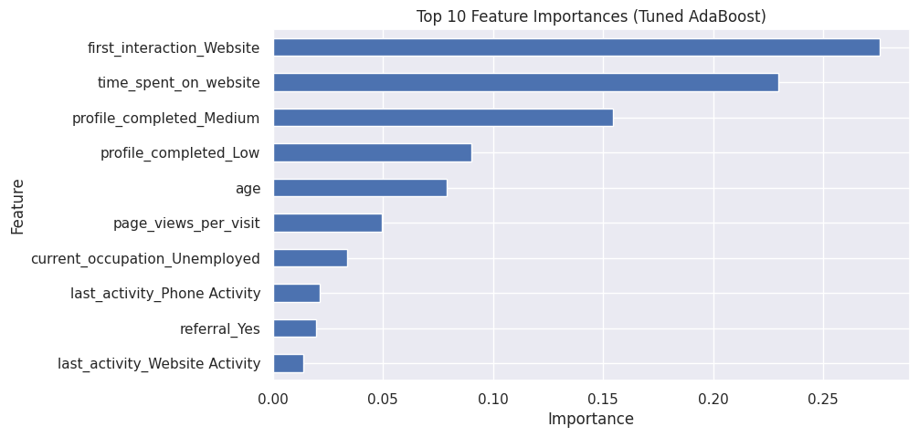

```python
# Display the model comparison table after Tuned AdaBoost and capture the sorted DataFrame
results_df_sorted = display_model_comparison_table(model_results)

# Plot confusion matrices for the top models (adjust n as needed to include the new model)
plot_top_n_confusion_matrices(model_results, results_df_sorted, min(len(model_results), 5)) # Display up to top 5 or fewer

# Display feature importance for the Tuned AdaBoost model
display_feature_importance(tuned_ada_model, X_train.columns, 'Tuned AdaBoost')
```

[output not shown]